# Project 3: Credit Card Default Detection

#### 1. Given the data below, please classify the two cluster data and find the boundary line to devide the two groups. Use visualization to show your answer.

```python
import numpy as np
import pandas as pd
import matplotlib.pyplot as plt
# % matplotlib inline
from sklearn import metrics
from sklearn import datasets, model_selection
import seaborn as sns

X,Y = datasets.make_blobs(n_samples=200, n_features=2, centers=2, random_state=2)
```

```python
# Define a function to plot the decision boundary
def plotDecisionBoundary(estimator, data, label, proba = True):
    h = .02  # step size in the mesh
    # create a mesh to plot in
    x_min, x_max = data[:, 0].min() - 1, data[:, 0].max() + 1
    y_min, y_max = data[:, 1].min() - 1, data[:, 1].max() + 1
    xx, yy = np.meshgrid(np.arange(x_min, x_max, h),
                         np.arange(y_min, y_max, h))
    test_x = np.array([x1 for x1 in zip(xx.ravel(), yy.ravel())])
    if proba == True:
        test_y = estimator.predict_proba(test_x)
        z = test_y[:,1].reshape(xx.shape)
    else:
        test_y = estimator.predict(test_x)
        z = test_y.reshape(xx.shape)

    plt.figure(figsize=(8, 8))
    plt.contourf(xx, yy, z, alpha=0.3)
    plt.scatter(data[:,0], data[:,1], c=label)


# Define a function to check the accuracy
def check_accuracy(label, prediction):
    print("Accuracy: ")
    print(metrics.accuracy_score(label, prediction))

    print("Precision: ")
    print(metrics.precision_score(label, prediction, pos_label=1))

    print("Recall: ")
    print(metrics.recall_score(label, prediction, pos_label=1))
```

```python
# Check the dimension of the input data

X.shape, Y.shape
```

```
((200, 2), (200,))
```

```python
# Check the distribution of the target

pd.Series(Y).value_counts()
```

```
1    100
0    100
dtype: int64
```

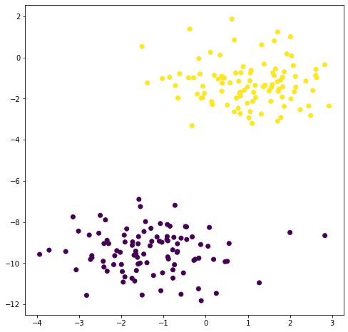

```python
# Visualize the input data

plt.figure(figsize=(8, 8))
plt.scatter(X[:,0], X[:,1], c=Y)
```

### 1. Logistic Regression Model

```python
from sklearn import linear_model
```

```python
lm_lr = linear_model.LogisticRegression()
lm_lr.fit(X, Y)
```

```
LogisticRegression()
```

```
Accuracy:
1.0
Precision:
1.0
Recall:
1.0
```

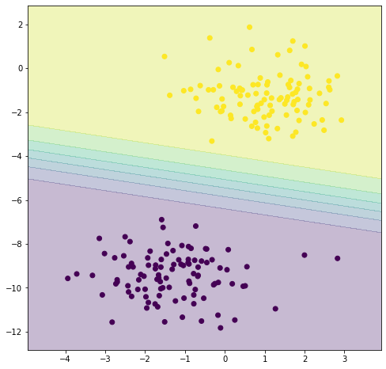

```python
plotDecisionBoundary(lm_lr, X, Y)
check_accuracy(Y, lm_lr.predict(X))
```

### 2. Support Vector Machine

```python
from sklearn.svm import SVC
```

```python
svc_model = SVC(gamma='auto', C = 0.01)
svc_model.fit(X, Y)
```

```
SVC(C=0.01, gamma='auto')
```

```
Accuracy:
1.0
Precision:
1.0
Recall:
1.0
```

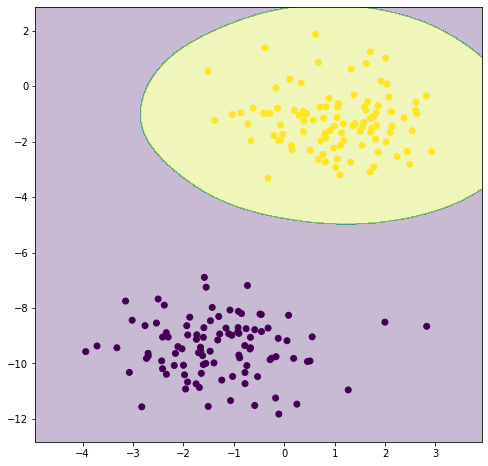

```python
plotDecisionBoundary(svc_model, X, Y, proba = False)
check_accuracy(Y, svc_model.predict(X))
```

### 3. Decision Tree

```python
from sklearn import tree
```

```python
t_dtc = tree.DecisionTreeClassifier(max_depth=3)
t_dtc.fit(X, Y)
```

```
DecisionTreeClassifier(max_depth=3)
```

```
Accuracy:
1.0
Precision:
1.0
Recall:
1.0
```

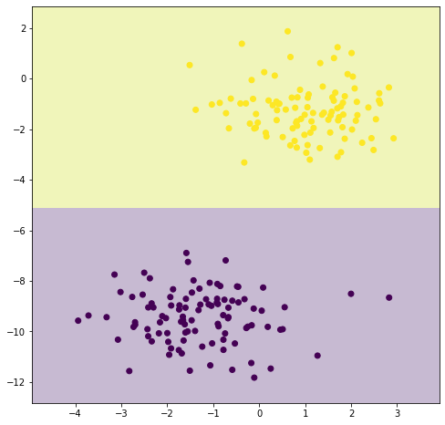

```python
plotDecisionBoundary(t_dtc, X, Y)
check_accuracy(Y, t_dtc.predict(X))
```

### 4. Random Forrest

```python
from sklearn.ensemble import RandomForestClassifier
```

```python
rand_forrest = RandomForestClassifier(n_estimators=10, max_depth=None, min_samples_split=4, random_state=0)
rand_forrest.fit(X, Y)
```

```
RandomForestClassifier(min_samples_split=4, n_estimators=10, random_state=0)
```

```
Accuracy:
1.0
Precision:
1.0
Recall:
1.0
```

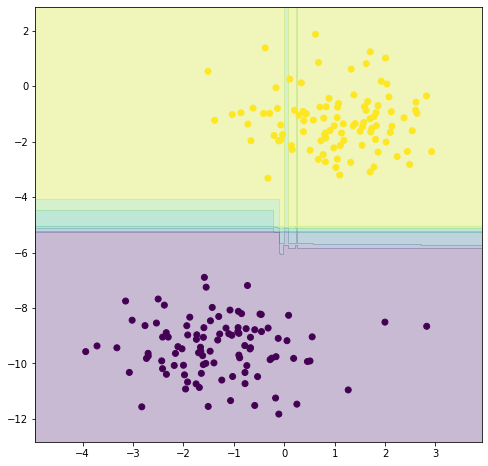

```python
plotDecisionBoundary(rand_forrest, X, Y)
check_accuracy(Y, rand_forrest.predict(X))
```

### 5. Extremely Randomized Trees

```python
from sklearn.ensemble import ExtraTreesClassifier
```

```python
extra_forrest = ExtraTreesClassifier(n_estimators=10, max_depth=None, min_samples_split=2, random_state=0)
extra_forrest.fit(X, Y)
```

```
ExtraTreesClassifier(n_estimators=10, random_state=0)
```

```
Accuracy:
1.0
Precision:
1.0
Recall:
1.0
```

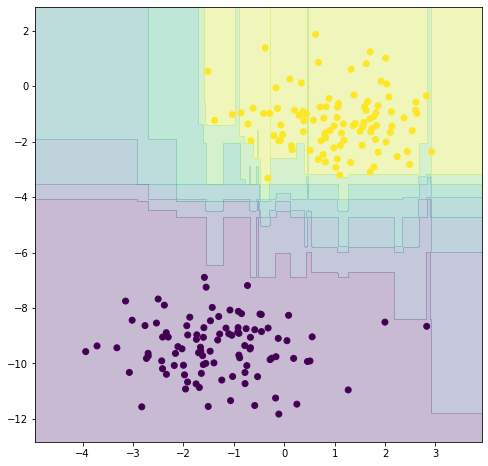

```python
plotDecisionBoundary(extra_forrest, X, Y)
check_accuracy(Y, extra_forrest.predict(X))
```

#### 2. Following you will need to solve a Credit Card Default Detection Case

- Credit Card Default
  - To default is to fail to make a payment on a debt by the due date. If this happens with a credit card, creditors might raise interest rates to the default (or penalty rate) or decrease the line of credit. In case of serious delinquency, the card issuer can even take legal action to enforce payment or to garnish wages.
- Objective
  - Our objective for this project is, given the data set, we are going to build a machine learning model to predict whether a credit card is going to default

**Data Description:**

**id**: A unique Id field which represents a customer

**X1**: Credit line

**X2**: Gender (1 = male; 2 = female).

**X3**: Education (1 = graduate school; 2 = university; 3 = high school; 4 = others).

**X4**: Marital status (1 = married; 2 = single; 3 = others).

**X5**: Age (year).

**X6 - X11**: History of past payment.

**X6** = September, 2015;

**X7** = August, 2015;

**X11** =April, 2015. -1 = pay one month ahead; -2 = pay two month ahead; 0 = pay on time; Positive means the payment delayed months, 1 = delay 1 month, 2 = delay 2 months, etc.

**X12- X17**: Amount in bill statement.

**X12** = amount of bill statementSeptember, 2015

**X13** = amount of bill statementAugust, 2015

**X17** = amount of bill statementApril, 2015.

**X18-X23**: Amount of previous payment

**X18** = amount paid in September, 2015;

**X19** = amount paid in August, 2015;

**X23** = amount paid in April, 2015.

**Y**: A binary response variable to indicate whether the credit card is default (1) or not (0).

This is a real problem to classify multi-feature data into two groups.

# Objective

- In this project, we are going to predict whether a credit card would be default or not. It's a classification problem where the label set is imbalanced since most of the credit cards are normal and only a few of them are default. For this project, we can not only have the chance to train a powerful classification model, but also tackle on the very important problem we might encounter in the future.

## Steps:

1. Perform feature engineering to the dataset the way you see fit.
2. Choose a classifier you like to make prediction
3. Keep in mind that the labels in target variable is imbalanced and figure out a way to deal with that problem

**Hint for steps**

1. Load data
2. There are so many features, please discern the categorical and continuous variables.
3. Check if features have linear relationship between each other.
4. Choose the proper method to train the model:
5. Evaluate your model.
6. Use your model to train the data. And make your submission file.

## 1. Data Reading

```python
input_raw = pd.read_csv('raw_data.csv')
```

## 2. Basic data analysis

### ---1) input data shape check

```python
# Check input data  shape

input_raw.shape
```

```
(25000, 25)
```

```python
input_raw.head()
```

|  | id | X1 | X2 | X3 | X4 | X5 | X6 | X7 | X8 | X9 | ... | X15 | X16 | X17 | X18 | X19 | X20 | X21 | X22 | X23 | Y |
| --- | --- | --- | --- | --- | --- | --- | --- | --- | --- | --- | --- | --- | --- | --- | --- | --- | --- | --- | --- | --- | --- |
| 0 | 1 | 200000 | 2 | 3 | 1 | 53 | 0 | 0 | 0 | 0 | ... | 133207 | 136159 | 138741 | 6500 | 5000 | 5000 | 5100 | 5000 | 5400 | 0 |
| 1 | 2 | 130000 | 2 | 3 | 2 | 39 | 0 | 0 | 0 | 2 | ... | 130814 | 130758 | 123468 | 7500 | 10000 | 0 | 4500 | 4500 | 4179 | 0 |
| 2 | 3 | 350000 | 2 | 1 | 2 | 41 | 0 | 0 | 0 | 0 | ... | 119947 | 117328 | 118400 | 6000 | 5900 | 5800 | 4100 | 4500 | 5000 | 0 |
| 3 | 4 | 240000 | 2 | 2 | 1 | 43 | 1 | -2 | -2 | -1 | ... | 12700 | 12500 | 26225 | 0 | 0 | 12700 | 0 | 13725 | 0 | 0 |
| 4 | 5 | 180000 | 1 | 2 | 2 | 28 | -1 | -1 | -1 | -1 | ... | 332 | 416 | 416 | 0 | 416 | 332 | 500 | 3500 | 832 | 0 |

5 rows × 25 columns

### ---2) Missing value check

```python
input_raw.isna().sum().sum()

# No missing value found
```

```
0
```

### ---3) Target distribution check

```python
# Check the distribution of the target

print(input_raw.Y.value_counts())
print(input_raw.Y.value_counts(normalize = True))

# Only 22.2% of data have Y = 1
```

```
0    19452
1     5548
Name: Y, dtype: int64
0    0.77808
1    0.22192
Name: Y, dtype: float64
```

### ---4) Data type check

```python
input_raw.dtypes

# All of them are integer numbers
```

```
id     int64
X1     int64
X2     int64
X3     int64
X4     int64
X5     int64
X6     int64
X7     int64
X8     int64
X9     int64
X10    int64
X11    int64
X12    int64
X13    int64
X14    int64
X15    int64
X16    int64
X17    int64
X18    int64
X19    int64
X20    int64
X21    int64
X22    int64
X23    int64
Y      int64
dtype: object
```

### ---5) Find out which features are categorical data

```python
# Find which column is categorical data

categorical_column = []

print("These are likely categorical features:")

for item in input_raw.columns:
    value_count = len(input_raw[item].unique())
    if  (value_count < 10) & (item != 'Y'):
        print("Feature name: {},  value count: {}". format(item, value_count))
        categorical_column.append(item)

print("Categorical columns saved: ", categorical_column)
```

```
These are likely categorical features:
Feature name: X2,  value count: 2
Feature name: X3,  value count: 7
Feature name: X4,  value count: 4
Categorical columns saved:  ['X2', 'X3', 'X4']
```

### ---6) Check if there is any linear correlation between different features

```
(25, 25)
```

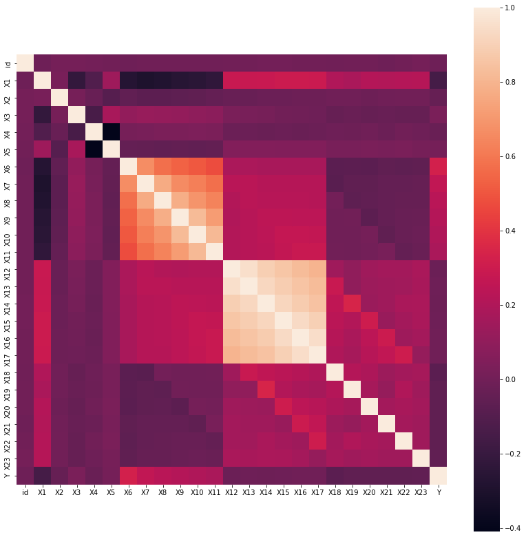

```python
# Show correlation matrix

corr_matrix = input_raw.corr()
print(corr_matrix.shape)

fig, ax = plt.subplots(figsize=(14,14))
sns.heatmap(corr_matrix, square = True)
```

### Observations:

```
- It seems that thre is relatively high correlation between features X12 - X17
- It makes sense since X12 - X17 are consecutive billing amounts. The billing amount of the current month is likely highly correlated with the billing amounts of the previous months

- Also, there is some correlation between features X6 - X11
- It also makes sense since X6 - X11 indicate the payment habit for one person. For the same person, it is very likely that he/she would pay on time or 1 month ahead or delay the payment most of the time
```

### ---7) Check the distribution of the features

### -------------credit line (X1)

```python
input_raw.X1.min(),input_raw.X1.max()
```

```
(10000, 800000)
```

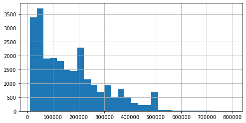

```python
fig, ax = plt.subplots(figsize=(8,4))
input_raw.X1.hist(bins = 30)

# This data is skewed
```

### -------------gender (X2)

```
2    0.60676
1    0.39324
Name: X2, dtype: float64
```

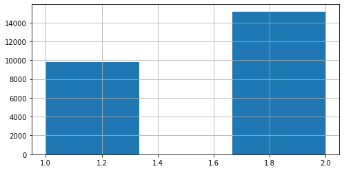

```python
print(input_raw.X2.value_counts(normalize = True))

fig, ax = plt.subplots(figsize=(8,4))
input_raw.X2.hist(bins = 3)

# Female is more than male
```

### -------------Education (X3)

```
2    0.46744
1    0.35288
3    0.16400
5    0.00916
4    0.00424
6    0.00180
0    0.00048
Name: X3, dtype: float64
```

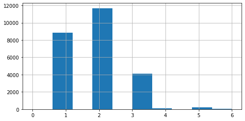

```python
print(input_raw.X3.value_counts(normalize = True))

fig, ax = plt.subplots(figsize=(8,4))
input_raw.X3.hist(bins = 10)

# Majority of people have university or higher degree
```

### -------------Marital Status (X4)

```
2    0.53324
1    0.45432
3    0.01080
0    0.00164
Name: X4, dtype: float64
```

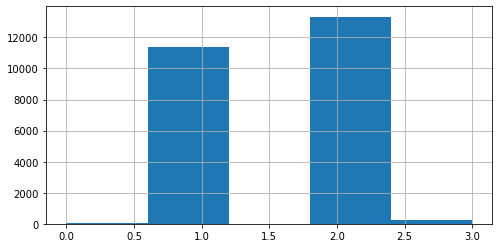

```python
print(input_raw.X4.value_counts(normalize = True))

fig, ax = plt.subplots(figsize=(8,4))
input_raw.X4.hist(bins = 5)
```

### -------------Age (X5)

```python
input_raw.X5.min(),input_raw.X5.max()
```

```
(21, 79)
```

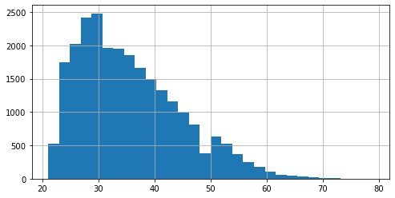

```python
fig, ax = plt.subplots(figsize=(8,4))
input_raw.X5.hist(bins = 30)

# This data is skewed
```

### -------------history of past payment (X6 - X11)

```python
input_raw.X6.min(),input_raw.X6.max()
```

```
(-2, 8)
```

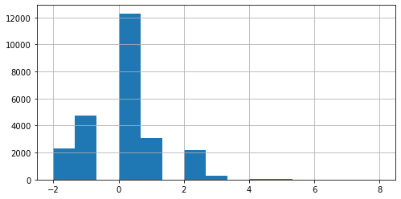

```python
fig, ax = plt.subplots(figsize=(8,4))
input_raw.X6.hist(bins = 15)
```

### -------------billing statement (X12 - X17)

```python
input_raw.X12.min(),input_raw.X12.max()

# There could be some outliars in the data. The billing amount can be nagetive?
```

```
(-165580, 746814)
```

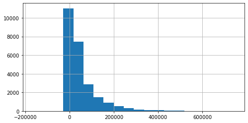

```python
fig, ax = plt.subplots(figsize=(8,4))
input_raw.X12.hist(bins = 20)
```

### ------------amount paid (X18 - X23)

```python
input_raw.X18.min(),input_raw.X23.max()

# There could be some outliars in the data. Some amount paid is much larger than the rest of the data
```

```
(0, 528666)
```

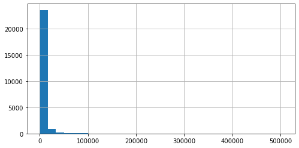

```python
fig, ax = plt.subplots(figsize=(8,4))
input_raw.X18.hist(bins = 30)
```

## 8) Use one hot to convert categorical features

```python
print("Categorical features: ", categorical_column)

input_onehot = input_raw.copy()

for item in categorical_column:
    one_hot = pd.get_dummies(input_raw[item], prefix= item)
    input_onehot = pd.concat((input_onehot, one_hot), axis = 1)

input_onehot = input_onehot.drop(columns = categorical_column)

input_onehot
```

```
Categorical features:  ['X2', 'X3', 'X4']
```

|  | id | X1 | X5 | X6 | X7 | X8 | X9 | X10 | X11 | X12 | ... | X3_1 | X3_2 | X3_3 | X3_4 | X3_5 | X3_6 | X4_0 | X4_1 | X4_2 | X4_3 |
| --- | --- | --- | --- | --- | --- | --- | --- | --- | --- | --- | --- | --- | --- | --- | --- | --- | --- | --- | --- | --- | --- |
| 0 | 1 | 200000 | 53 | 0 | 0 | 0 | 0 | 0 | 0 | 126027 | ... | 0 | 0 | 1 | 0 | 0 | 0 | 0 | 1 | 0 | 0 |
| 1 | 2 | 130000 | 39 | 0 | 0 | 0 | 2 | 0 | 0 | 133825 | ... | 0 | 0 | 1 | 0 | 0 | 0 | 0 | 0 | 1 | 0 |
| 2 | 3 | 350000 | 41 | 0 | 0 | 0 | 0 | 0 | 0 | 122017 | ... | 1 | 0 | 0 | 0 | 0 | 0 | 0 | 0 | 1 | 0 |
| 3 | 4 | 240000 | 43 | 1 | -2 | -2 | -1 | 0 | 0 | 0 | ... | 0 | 1 | 0 | 0 | 0 | 0 | 0 | 1 | 0 | 0 |
| 4 | 5 | 180000 | 28 | -1 | -1 | -1 | -1 | -1 | -1 | 1832 | ... | 0 | 1 | 0 | 0 | 0 | 0 | 0 | 0 | 1 | 0 |
| ... | ... | ... | ... | ... | ... | ... | ... | ... | ... | ... | ... | ... | ... | ... | ... | ... | ... | ... | ... | ... | ... |
| 24995 | 24996 | 300000 | 56 | 1 | -2 | -2 | -2 | -2 | -2 | 0 | ... | 1 | 0 | 0 | 0 | 0 | 0 | 0 | 1 | 0 | 0 |
| 24996 | 24997 | 230000 | 36 | 0 | 0 | 0 | 2 | 0 | 0 | 3745 | ... | 0 | 1 | 0 | 0 | 0 | 0 | 0 | 1 | 0 | 0 |
| 24997 | 24998 | 30000 | 23 | 2 | 2 | 2 | 2 | 2 | 2 | 34048 | ... | 0 | 1 | 0 | 0 | 0 | 0 | 0 | 0 | 1 | 0 |
| 24998 | 24999 | 360000 | 36 | 0 | 0 | 0 | 0 | 0 | 0 | 28291 | ... | 1 | 0 | 0 | 0 | 0 | 0 | 0 | 1 | 0 | 0 |
| 24999 | 25000 | 320000 | 41 | -2 | -2 | -2 | -2 | -2 | -2 | 2197 | ... | 1 | 0 | 0 | 0 | 0 | 0 | 0 | 0 | 1 | 0 |

25000 rows × 35 columns

## 9) Remove highly correlated features and outliars

### -------- Since X12-X17 are highly correlated, we may just keep one of them (Say, keep only X12)

### -------- Since X6-X11 are also correlated, we may just keep one or two of them (Say, keep only X6 and X11)

```python
input_onehot_feature_edit = input_onehot.copy()
input_onehot_feature_edit.shape
```

```
(25000, 35)
```

```python
input_onehot_feature_edit = input_onehot_feature_edit.drop(columns = ['X13', 'X14', 'X15', 'X16', 'X17', 'X7', 'X8', 'X9', 'X10'])
input_onehot_feature_edit.shape
```

```
(25000, 26)
```

### -------Billing statement (X12) has some large negative values which we may need to discard

```python
(input_onehot_feature_edit.X12 < -5000).sum()
```

```
15
```

```python
input_onehot_feature_edit = input_onehot_feature_edit[input_onehot_feature_edit.X12 > (-5000)]
input_onehot_feature_edit.shape
```

```
(24985, 26)
```

### ------- The amount pay (X18 - X23) has some very large values which we may need to discard

```python
(input_onehot_feature_edit.X23 > 200000).sum()
```

```
39
```

```python
input_onehot_feature_edit = input_onehot_feature_edit[input_onehot_feature_edit.X23 < 200000]
input_onehot_feature_edit.shape
```

```
(24944, 26)
```

## 10) Apply log function to features that have skewed distribution

### ---------credit line (X1)

```python
input_onehot_feature_edit['log_X1'] = np.log(input_onehot_feature_edit['X1'])
input_onehot_feature_edit.shape
```

```
(24944, 27)
```

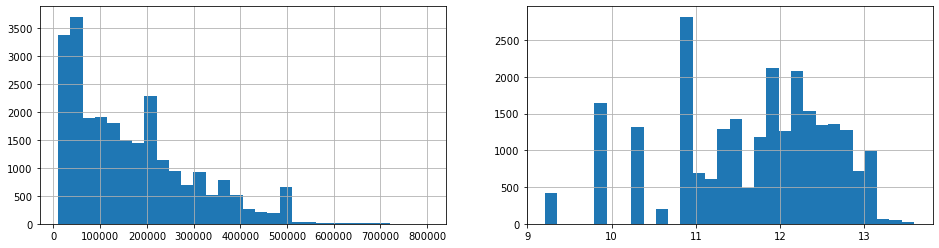

```python
fig = plt.figure(figsize = (16,4))
fig.add_subplot(121)
input_onehot_feature_edit.X1.hist(bins = 30)
fig.add_subplot(122)
input_onehot_feature_edit.log_X1.hist(bins = 30)
```

### ---------AGE (X5)

```python
input_onehot_feature_edit['log_X5'] = np.log(input_onehot_feature_edit['X5'])
input_onehot_feature_edit.shape
```

```
(24944, 28)
```

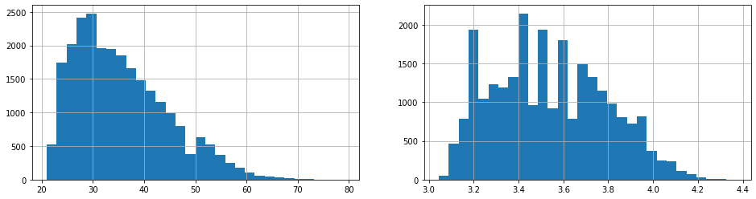

```python
fig = plt.figure(figsize = (16,4))
fig.add_subplot(121)
input_onehot_feature_edit.X5.hist(bins = 30)
fig.add_subplot(122)
input_onehot_feature_edit.log_X5.hist(bins = 30)
```

```python
# Remove X1 and X5 and only keep the log features

input_onehot_feature_edit = input_onehot_feature_edit.drop(columns = ['X1', 'X5'])
input_onehot_feature_edit.shape
```

```
(24944, 26)
```

### -------------billing statement (X12)

```python
# Since amount paid has negative values, we need to add some constant to prevent having -inf

input_onehot_feature_edit['log_X12'] = np.log(input_onehot_feature_edit['X12'] + 5000)
input_onehot_feature_edit.shape
```

```
(24944, 27)
```

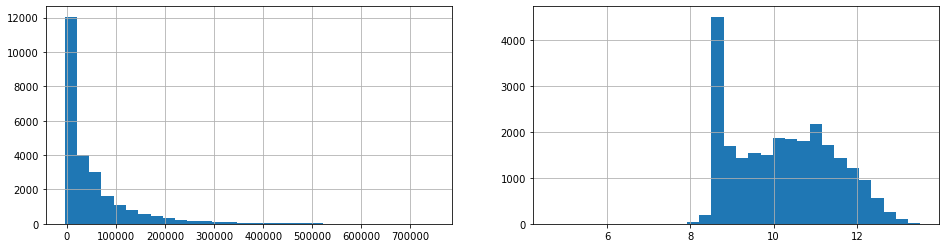

```python
fig = plt.figure(figsize = (16,4))
fig.add_subplot(121)
input_onehot_feature_edit.X12.hist(bins = 30)
fig.add_subplot(122)
input_onehot_feature_edit.log_X12.hist(bins = 30)
```

### -----------amount paid (X18 - X23)

```python
# Since amount paid has zero values, we need to add some constant to prevent having -inf

input_onehot_feature_edit['log_X18'] = np.log(input_onehot_feature_edit['X18'] + 100)
input_onehot_feature_edit['log_X19'] = np.log(input_onehot_feature_edit['X19'] + 100)
input_onehot_feature_edit['log_X20'] = np.log(input_onehot_feature_edit['X20'] + 100)
input_onehot_feature_edit['log_X21'] = np.log(input_onehot_feature_edit['X21'] + 100)
input_onehot_feature_edit['log_X22'] = np.log(input_onehot_feature_edit['X22'] + 100)
input_onehot_feature_edit['log_X23'] = np.log(input_onehot_feature_edit['X23'] + 100)
input_onehot_feature_edit.shape
```

```
(24944, 33)
```

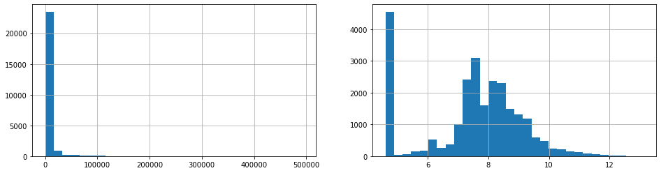

```python
fig = plt.figure(figsize = (16,4))
fig.add_subplot(121)
input_onehot_feature_edit.X18.hist(bins = 30)
fig.add_subplot(122)
input_onehot_feature_edit.log_X18.hist(bins = 30)
```

## 11) Prepare the train and test data

```python
X = input_onehot_feature_edit.drop(columns = ['id', 'Y'])
Y = input_onehot_feature_edit['Y']
```

```python
X.head()
```

|  | X6 | X11 | X12 | X18 | X19 | X20 | X21 | X22 | X23 | X2_1 | ... | X4_3 | log_X1 | log_X5 | log_X12 | log_X18 | log_X19 | log_X20 | log_X21 | log_X22 | log_X23 |
| --- | --- | --- | --- | --- | --- | --- | --- | --- | --- | --- | --- | --- | --- | --- | --- | --- | --- | --- | --- | --- | --- |
| 0 | 0 | 0 | 126027 | 6500 | 5000 | 5000 | 5100 | 5000 | 5400 | 0 | ... | 0 | 12.206073 | 3.970292 | 11.783159 | 8.794825 | 8.536996 | 8.536996 | 8.556414 | 8.536996 | 8.612503 |
| 1 | 0 | 0 | 133825 | 7500 | 10000 | 0 | 4500 | 4500 | 4179 | 0 | ... | 0 | 11.775290 | 3.663562 | 11.840969 | 8.935904 | 9.220291 | 4.605170 | 8.433812 | 8.433812 | 8.361475 |
| 2 | 0 | 0 | 122017 | 6000 | 5900 | 5800 | 4100 | 4500 | 5000 | 0 | ... | 0 | 12.765688 | 3.713572 | 11.752076 | 8.716044 | 8.699515 | 8.682708 | 8.342840 | 8.433812 | 8.536996 |
| 3 | 1 | 0 | 0 | 0 | 0 | 12700 | 0 | 13725 | 0 | 0 | ... | 0 | 12.388394 | 3.761200 | 8.517193 | 4.605170 | 4.605170 | 9.457200 | 4.605170 | 9.534234 | 4.605170 |
| 4 | -1 | -1 | 1832 | 0 | 416 | 332 | 500 | 3500 | 832 | 1 | ... | 0 | 12.100712 | 3.332205 | 8.829373 | 4.605170 | 6.246107 | 6.068426 | 6.396930 | 8.188689 | 6.837333 |

5 rows × 31 columns

```python
Y.head()
```

```
0    0
1    0
2    0
3    0
4    0
Name: Y, dtype: int64
```

```python
X_train, X_test, Y_train, Y_test = model_selection.train_test_split(X, Y, train_size=0.75)
```

```python
X_train.shape, Y_train.shape, X_test.shape, Y_test.shape
```

```
((18708, 31), (18708,), (6236, 31), (6236,))
```

```python
Y_train.value_counts(normalize = True)
```

```
0    0.778063
1    0.221937
Name: Y, dtype: float64
```

```python
Y_test.value_counts(normalize = True)
```

```
0    0.777421
1    0.222579
Name: Y, dtype: float64
```

## 12) Model fitting

```python
def check_accuracy_v2(label, prediction):
    print("Accuracy: ")
    print(metrics.accuracy_score(label, prediction))

    print("Precision: ")
    print(metrics.precision_score(label, prediction, pos_label=1))

    print("Recall: ")
    print(metrics.recall_score(label, prediction, pos_label=1))

    print("f1 score: ")
    print(metrics.f1_score(label, prediction, pos_label=1))
```

### -----1) Logistical Regression

```python
credit_lm_lr = linear_model.LogisticRegression(max_iter = 5000)
%time credit_lm_lr.fit(X_train, Y_train)
```

```
Wall time: 93.7 ms
```

```
LogisticRegression(max_iter=5000)
```

```python
print("For training data:")
check_accuracy_v2(Y_train, credit_lm_lr.predict(X_train))
print()
print("For testing data:")
check_accuracy_v2(Y_test, credit_lm_lr.predict(X_test))
```

```
For training data:
Accuracy:
0.7781163138764166
Precision:
1.0
Recall:
0.00024084778420038535
f1 score:
0.0004815795810257645

For testing data:
Accuracy:
0.777421423989737
Precision:
0.0
Recall:
0.0
f1 score:
0.0
```

### ------2) Support Vector machine

```python
credit_svc_model = SVC(gamma='auto', C = 0.1)
%time  credit_svc_model.fit(X_train, Y_train)
```

```
Wall time: 1min 36s
```

```
SVC(C=0.1, gamma='auto')
```

```python
print("For training data:")
check_accuracy_v2(Y_train, credit_svc_model.predict(X_train))
print()
print("For testing data:")
check_accuracy_v2(Y_test, credit_svc_model.predict(X_test))
```

```
For training data:
Accuracy:
0.7802544366046611
Precision:
0.9361702127659575
Recall:
0.010597302504816955
f1 score:
0.020957370802572043

For testing data:
Accuracy:
0.7795060936497755
Precision:
0.9333333333333333
Recall:
0.010086455331412104
f1 score:
0.019957234497505347
```

### ------3) Decision Tree

```python
credit_t_dtc = tree.DecisionTreeClassifier(max_depth=6)
%time  credit_t_dtc.fit(X_train, Y_train)
```

```
Wall time: 132 ms
```

```
DecisionTreeClassifier(max_depth=6)
```

```python
print("For training data:")
check_accuracy_v2(Y_train, credit_t_dtc.predict(X_train))
print()
print("For testing data:")
check_accuracy_v2(Y_test, credit_t_dtc.predict(X_test))
```

```
For training data:
Accuracy:
0.8267051528757751
Precision:
0.7006172839506173
Recall:
0.38270712909441235
f1 score:
0.4950155763239875

For testing data:
Accuracy:
0.8159076330981399
Precision:
0.6639344262295082
Recall:
0.35014409221902015
f1 score:
0.4584905660377358
```

### -----4) Random forrest

```python
credit_rand_forrest = RandomForestClassifier(n_estimators=100, max_depth=None, min_samples_split=4, random_state=0)
%time credit_rand_forrest.fit(X_train, Y_train)
```

```
Wall time: 3.87 s
```

```
RandomForestClassifier(min_samples_split=4, random_state=0)
```

```python
print("For training data:")
check_accuracy_v2(Y_train, credit_rand_forrest.predict(X_train))
print()
print("For testing data:")
check_accuracy_v2(Y_test, credit_rand_forrest.predict(X_test))
```

```
For training data:
Accuracy:
0.9938528971562968
Precision:
0.998026153466568
Recall:
0.9742292870905588
f1 score:
0.9859841560024375

For testing data:
Accuracy:
0.8139833226427197
Precision:
0.6642651296829971
Recall:
0.33213256484149856
f1 score:
0.44284341978866476
```

### -----5) XGboost

```python
import xgboost as xgb
```

```python
xg_train = xgb.DMatrix(X_train, label = Y_train)
xg_test = xgb.DMatrix(X_test, Y_test)
```

```python
param = {
    'max_depth': 5,
    'eta': 0.3,
    'objective': 'binary:hinge',
}

epoch = 500

%time credit_xg_model = xgb.train(param, xg_train, epoch)
```

```
Wall time: 4.95 s
```

```python
print("For training data:")
check_accuracy_v2(Y_train, credit_xg_model.predict(xg_train))
print()
print("For testing data:")
check_accuracy_v2(Y_test, credit_xg_model.predict(xg_test))
```

```
For training data:
Accuracy:
0.8518815480008552
Precision:
0.769831965611567
Recall:
0.47447013487475914
f1 score:
0.5870958128445835

For testing data:
Accuracy:
0.8115779345734445
Precision:
0.6377749029754204
Recall:
0.35518731988472624
f1 score:
0.4562702452568255
```